# Distributions

Workshop on Statistics for Linguistics

Sky Onosson, University of Manitoba

## Agenda

- Normal distributions
- Testing of distributions: t-tests, ANOVAs

## Load required packages and LIPP data

```r
if(!require(tidyverse)){install.packages("tidyverse")}
library(tidyverse)

if(!require(viridis)){install.packages("viridis")}
library(viridis)

LIPP <- read_csv("LIPP.csv")
```

# 1 Normal distributions

Let’s look at a quickplot of F2 in the LIPP data.

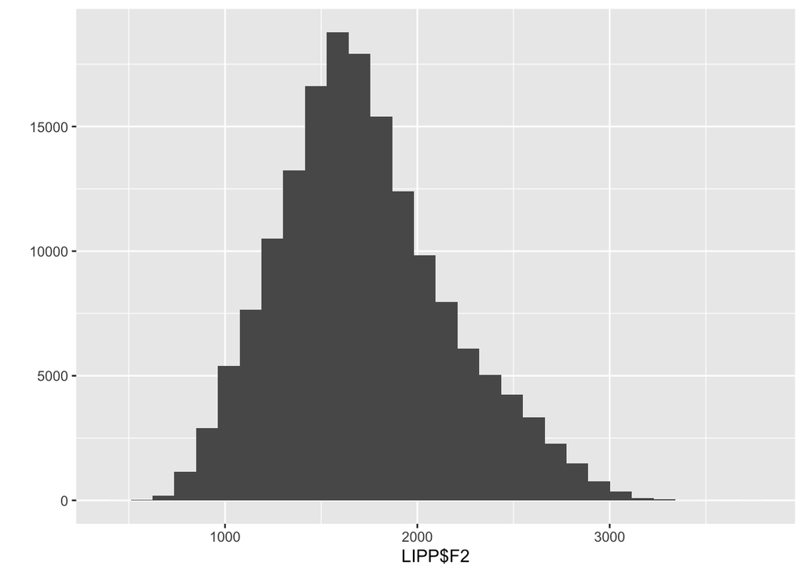

```r
qplot(LIPP$F2)
```

We can use R to generate a *random* normal distribution to see how this works. To do this I will use a custom function - so let’s learn how to do that.

## Custom functions (brief tangent)

Every R package contains a set of custom functions, and it’s possible to build your own functions in exactly the same way using the built in R function called, appropriately, `function()`. A function consists of a list of `arguments`, which are input into the function, and an `expression` which produces some output.

Let’s say we wanted to create a function to determine the difference between the mean and the median in a set of data. We could do this manually by getting each value and then subtracting one from the other:

```r
mean(LIPP$F2)
```

```
## [1] 1721.989
```

```r
median(LIPP$F2)
```

```
## [1] 1675.8
```

```r
1721.989-1675.8
```

```
## [1] 46.189
```

What would a function to do this look like? It’s quite simple. We provide a name for the function - let’s call it `mm_diff` - followed by the assignment operator. Then the `function()` function with the single argument that we want to be input into the function. This can be called anything we want, and is only used inside the function - let’s just call it `input`. Finally we put a space, and the formula we want to use for the expression. We can have anything we want here including other functions - in this case we want to take the `mean()` and `median()` of the `input` argument, and subtract them:

```r
mm_diff <- function(input) mean(input)-median(input)
```

Running this code creates the function, which we can now use:

```r
mm_diff(LIPP$F2)
```

```
## [1] 46.18854
```

One last point - what if we calculate our mean and median in the opposite order before subtracting?

```r
median(LIPP$F2)
```

```
## [1] 1675.8
```

```r
mean(LIPP$F2)
```

```
## [1] 1721.989
```

```r
1675.8-1721.989
```

```
## [1] -46.189
```

We end up with a negative value this time, but we really just want to know how far apart the values are regardless of direction. The solution is to take the absolute value of the difference, which disregards the positive/negative sign of the result, using the `abs()` function:

```r
median(LIPP$F2)
```

```
## [1] 1675.8
```

```r
mean(LIPP$F2)
```

```
## [1] 1721.989
```

```r
abs(1675.8-1721.989)
```

```
## [1] 46.189
```

Let’s redefine our formula to include `abs()`:

```r
mm_diff <- function(input) abs(mean(input)-median(input))
```

Now this formula will give us a positive value for the difference between the mean and median of any distribution, no matter which is greater than the other. Ok, back to normal distributions…

## Normal distributions (continued)

I’m going to create a formula which will generate a set of random numbers and produce a histogram of the resulting distribution along with information on the number of observations, the mean, the median, and the (absolute) difference between them.

The base R function to generate a random set of numbers in a normal distribution is `rnorm()`. It takes three numbers as arguments - the number of observations, the central value of the distribution, and the Standard Deviation (S.D.). S.D. is a measure of variance in the sample data being examined – a low S.D. indicates that most values are close to the mean, while larger values indicate that they are more spread out - I won’t go into the formula for calcultating this. Here’s a random set of 10 numbers from a normal distribution centred at 0 with an S.D. of 100:

```r
rnorm(10, 0, 100)
```

```
##  [1]   -0.9363273  -26.8467661  -72.3108065  -17.0114738  -71.6400159
##  [6] -177.2985799  -51.7874437   25.0622518   18.5905041  -58.2873183
```

By the way, we can get the S.D. of this distribution by putting the `rnorm` function inside the `sd()` function. Would you expect the result to be 100? Let’s see:

```r
sd(rnorm(10, 0, 100))
```

```
## [1] 111.5636
```

Since this is a random set, we won’t get the same numbers every time - and the S.D. is *not* 100 every time! Try running the code above over and over - the result changes because it generates a different random set of numbers every time. But the average of the S.D.s, given enough time, would settle down to about 100 eventually.

Ok back to the formula I was making. This formula will use `rnorm` to create a random set of observations, and produce a histogram. Let’s start with the random numbers. I’ll use the same centre of zero and S.D. of 100 every time, so the formula will only take one piece of input - the number of observations, or `n`:

```r
MyRandomHistogram <- function(n) rnorm(n, 0, 100)
```

We can try the formula:

```r
MyRandomHistogram(10)
```

```
##  [1]  203.679273   15.501658  305.528258 -121.653793  114.008785   25.657012
##  [7]    6.057619  -57.741509    4.604527  289.786204
```

Ok so this produces a set of 10 numbers, but not a histogram. To get the histogram we need a plot (I’ll use `qplot()` to keep it simple) with the random generator inside it. Let’s set a larger number of observations, 50:

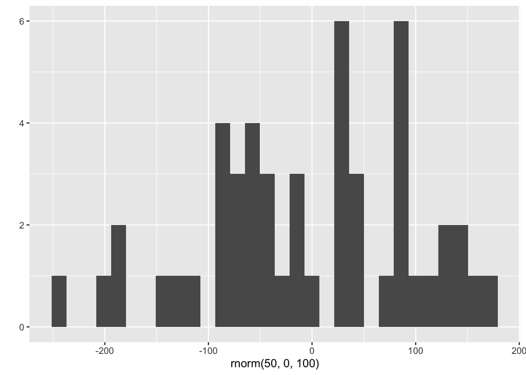

```r
qplot(rnorm(50, 0, 100))
```

Let’s add that to the function:

```r
MyRandomHistogram <- function(n) qplot(rnorm(n, 0, 100))
```

Now we can use the function, give it one number and get a random histogram

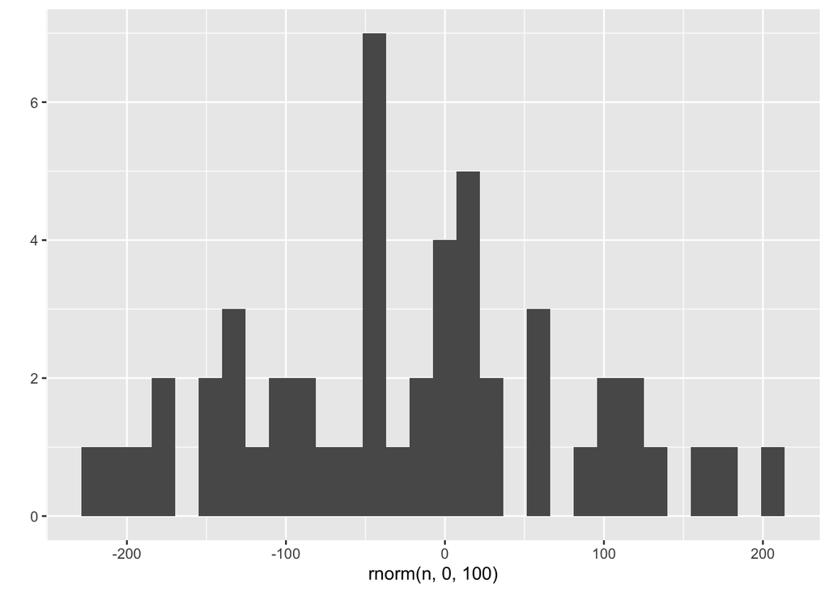

```r
MyRandomHistogram(50)
```

Notice that this histogram is different from the previous one even with the same number of observations, because they are randomly generated.

The final thing I want to do with the function is to replace the x-axis title with some information on the number of observations, the mean and median values, and their difference. It’s easty to add text to the qplot with the `xlab()` (for “x-label”) function:

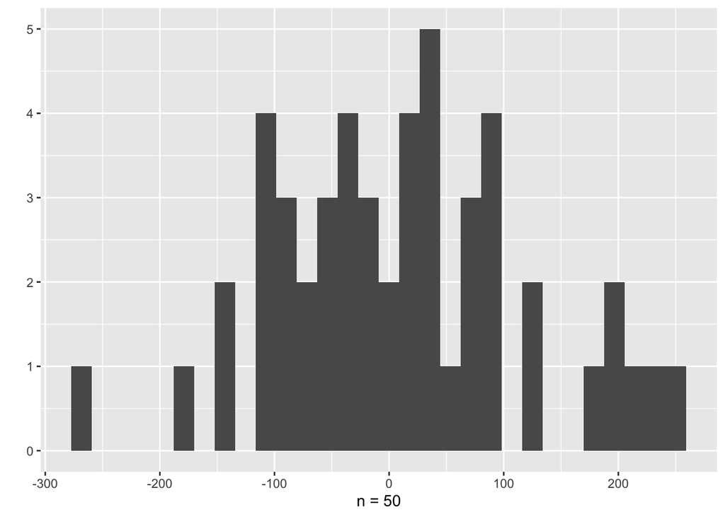

```r
qplot(rnorm(50, 0, 100)) +
  xlab("n = 50")
```

To build all of this info into the title, I’m going to use the `paste()` function which simply “pastes” a series of elements together as text.

```r
paste(50, mean(50), median(50))
```

```
## [1] "50 50 50"
```

If we put the random generator inside the functions in `paste()`, we get:

```r
paste(50, mean(rnorm(50, 0, 100)), median(rnorm(50, 0, 100)))
```

```
## [1] "50 3.19160765680132 1.83772283904505"
```

This is accurate but a little hard to read, so I’ll add text in between:

```r
paste("n =", 50,
      "; mean =", mean(rnorm(50, 0, 100)),
      "; median =", median(rnorm(50, 0, 100)))
```

```
## [1] "n = 50 ; mean = 30.4147648384709 ; median = -20.1189950354702"
```

Lastly, the difference between mean and median:

```r
paste("n =", 50,
      "; mean =", mean(rnorm(50, 0, 100)),
      "; median =", median(rnorm(50, 0, 100)),
      "; difference =", abs(mean(rnorm(50, 0, 100))
                       -median(rnorm(50, 0, 100))))
```

```
## [1] "n = 50 ; mean = 15.7417623246719 ; median = -4.2914813342925 ; difference = 28.3591721404915"
```

We can now add that to the formula, inside `xlab()`:

```r
MyRandomHistogram <- function(n)
  qplot(rnorm(n, 0, 100)) +
  xlab(paste("n =", n,
      "; mean =", mean(rnorm(n, 0, 100)),
      "; median =", median(rnorm(n, 0, 100)),
      "; difference =", abs(mean(rnorm(n, 0, 100))
                       -median(rnorm(n, 0, 100)))))
```

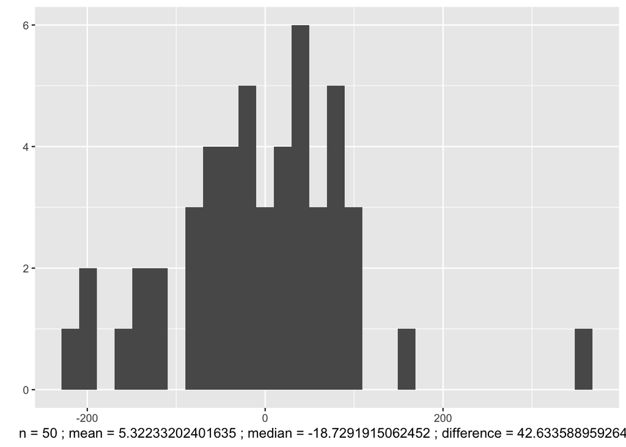

```r
MyRandomHistogram(50)
```

What this is intended to illustrate is how a *random set of observations* from a normal distribution is not itself necessarily normally distributed. A true normal distribution will have an identical mean and median, with a difference of zero, and will produce a bell-shaped histogram. This is not what we get using only 50 observations. Sometimes a bell-like shape appears, sometimes not. And rarely are the mean and median extremely close together.

The more observations we add, however, the closer we get to a normal distribution. Let’s see what happens by making a series of histograms using sets of random numbers containing just 10 observations, all the way up to 100,000 observations.

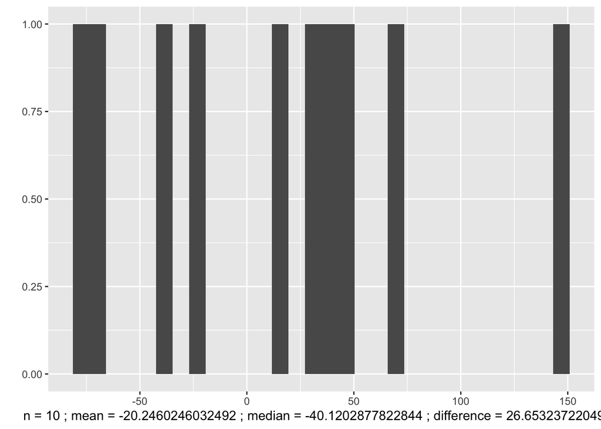

```r
MyRandomHistogram(10)
```

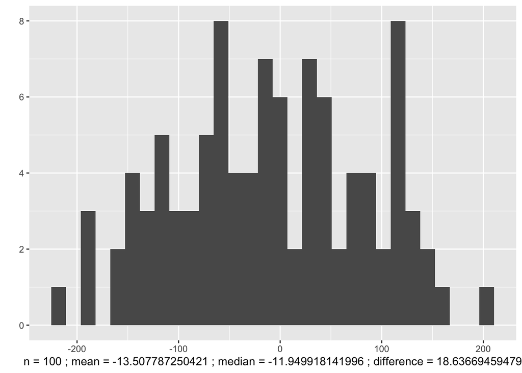

```r
MyRandomHistogram(100)
```

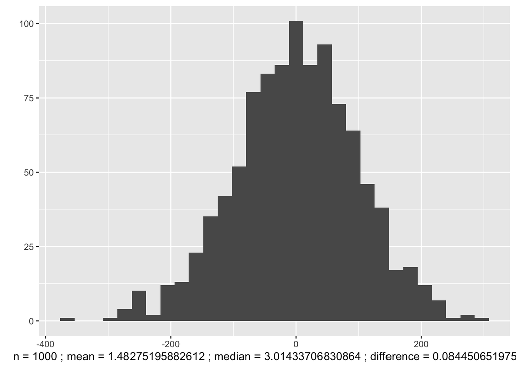

```r
MyRandomHistogram(1000)
```

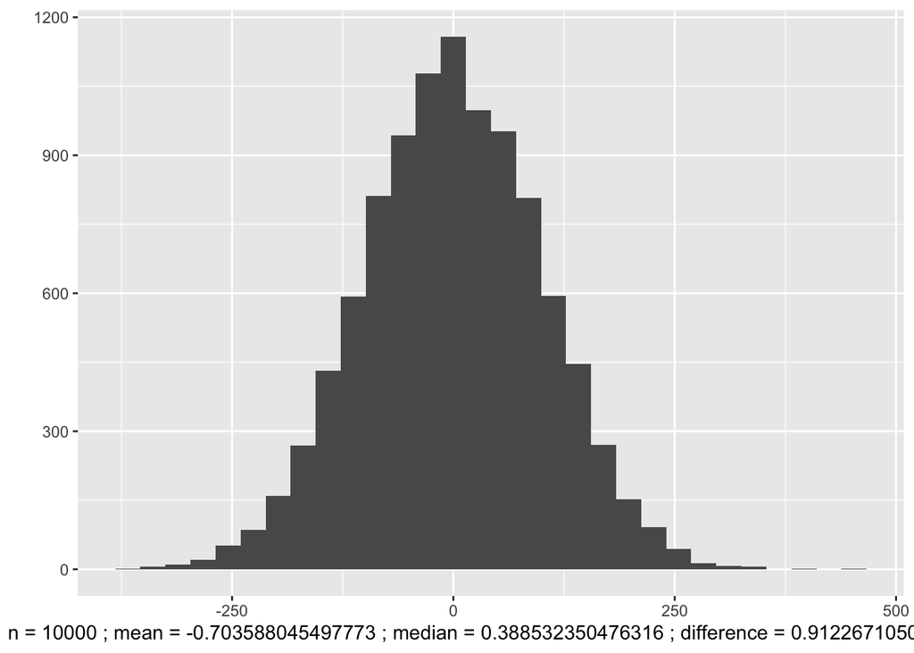

```r
MyRandomHistogram(10000)
```

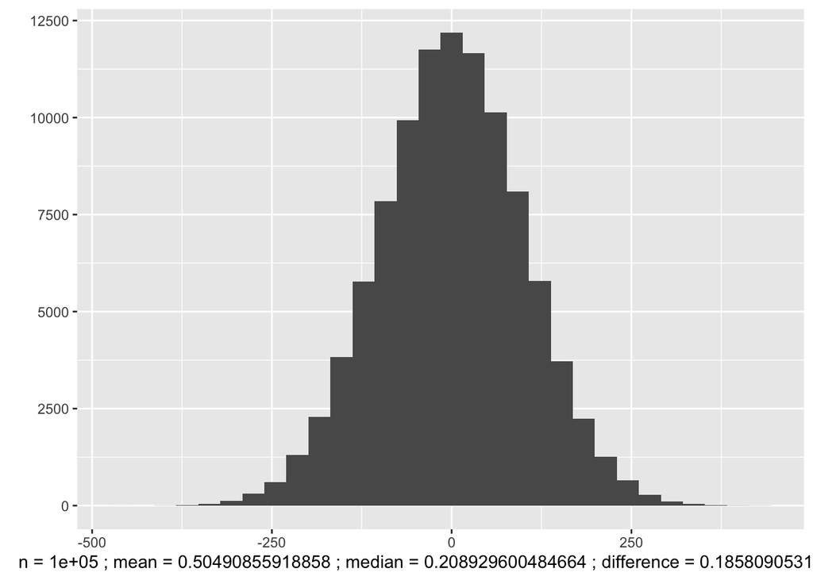

```r
MyRandomHistogram(100000)
```

You should get 5 randomly-generated histograms of observations drawn from a normal distribution. Because these are random, everyone will have a different set of results every time they run the above code. If you look through the histograms from smallest to largest n, the mean and median should get progressively closer together. This will not always be the case, however - you may get (small) increases in the difference even when n goes up, because of the randomness. But the final n=100,000 set should have a very small difference, close to zero.

Typically at 10 observations there is very little evidence of any kind of structure, while at 100 observations something of a bell-like curve usually emerges as the mean and median approach each other. At 1,000 observations the difference between these measures is usually quite small, and the distribution is clearly approaching the normal curve – beyond this, at 10,000 or 100,000 observations, there are diminishing returns to be had as the difference between the mean and median approaches zero.

How “normal” is the data in LIPP? Let’s look at F2:

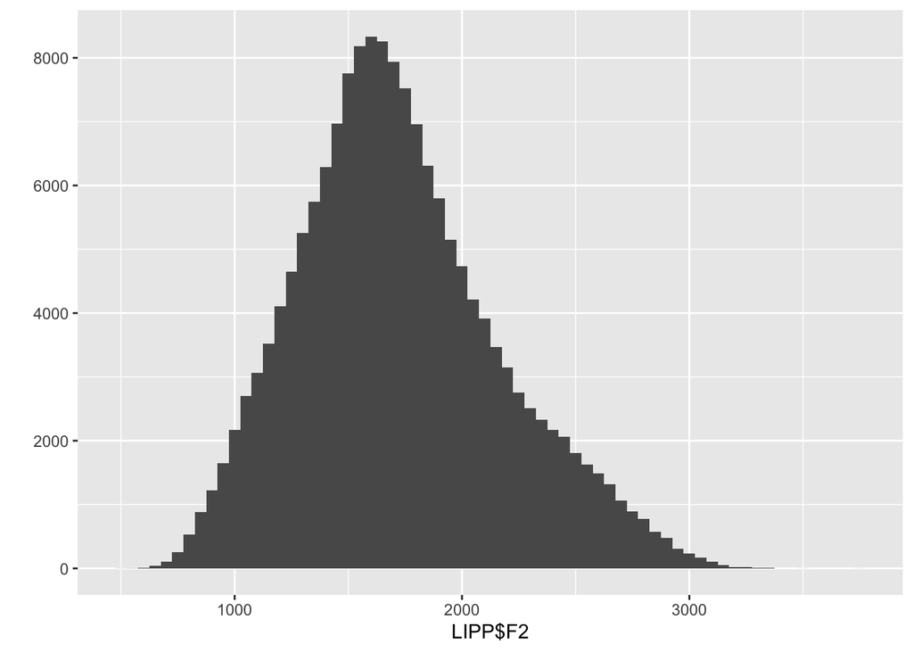

```r
qplot(LIPP$F2, binwidth = 50)
```

While the overall shape of this distribution is “bell-like” it is notably shifted or “skewed” towards one side, the lower end or left edge of the scale.

A useful visual assessment tool when it comes to normal distributions is the “quantile-to-quantile” or Q-Q plot. `qqnorm()` plots the Q-Q distribution of the data and `qqline()` adds a diagonal line indictaing where a normally-distributed dataset having the same mean and S.D. as the sample data would be.

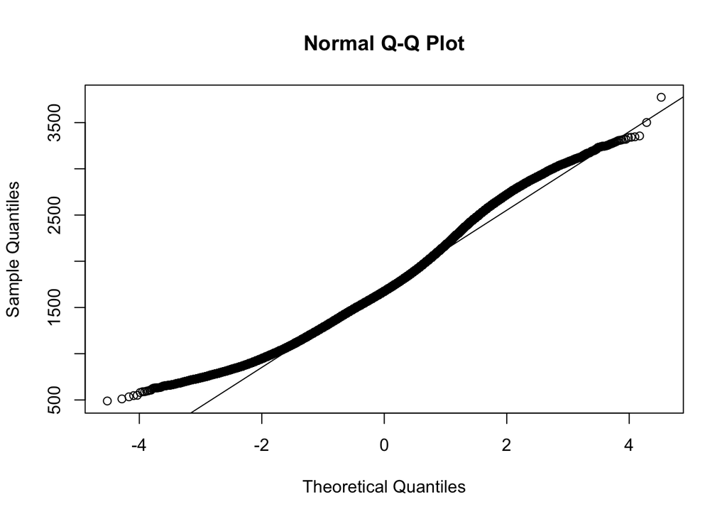

```r
qqnorm(LIPP$F2)
qqline(LIPP$F2)
```

The closer a set of observations adhere to the diagonal line in a Q-Q plot, the more normal their distribution. We see that especially at the lower end of the F2 scale, the distribution skews away from the normal line *to some extent*. But what does this mean precisely?

To do this, we have to subset the data. This is done in R by putting square brackets after the variable and indicating the item or range of items you want to select. For example, we could select just the 1st F2 observation, or the 27th, or the 103rd through 109th:

```r
LIPP$F2[1]
```

```
## [1] 1545.7
```

```r
LIPP$F2[27]
```

```
## [1] 1914.9
```

```r
LIPP$F2[103:109]
```

```
## [1] 2224.0 1089.3 1171.5 1182.0 1540.3 1716.8 1649.3
```

Let’s run the Shapiro-Wilk test on the first 5000 observations of F2:

```r
shapiro.test(LIPP$F2[1:5000])
```

```
##
##  Shapiro-Wilk normality test
##
## data:  LIPP$F2[1:5000]
## W = 0.99658, p-value = 2.55e-09
```

The Shapiro-Wilk test takes as its null hypothesis that the set of observations being tested *do* come from a normal distribution. Finding a significant result as indicated by the *p* value indicates that we must *reject the null hypothesis* and conclude that the distribution is *not* normal (or, at least not perfectly normal).

This is not the only output from the test, however. The *W* score indicates the degree of deviation from normality, with 1.0 indicating a perfectly normal distribution and lower values indicating less normal distributions. The indicated value of 0.99658 is very, very close to 1.0. Combining our observations of the frequency plot, Q-Q plot, and the Shapiro-Wilk test, we should conclude that the distribution of F2 in LIPP is fairly normal, but is skewed slightly, mostly in its lower range.

> See this page for a discussion of how the Shapiro-Wilk test performs over many random datasets, and in particular how to evaluate the *W*-score: https://emilkirkegaard.dk/en/?p=4452

Why test for normality? If a distribution is normal, this indicates the applicability of a range of parametric tests. However, for non-normal distributions, statisticians advise either transforming the data somehow, e.g. by taking the log or square root, or use one of a several non-parametric tests. In general parametric tests are more sensitive, especially for smaller datasets, so it is important to know how the data is distributed and take appropriate measures. However, as we’ll see below, it often turns out that this is unnecessary when very large datasets are involved.

# 2 Testing of distributions: *t*-tests, ANOVAs and related tests

## 2.1 *t*-tests

A while ago we looked at the differences in F2 distribution by speaker sex:

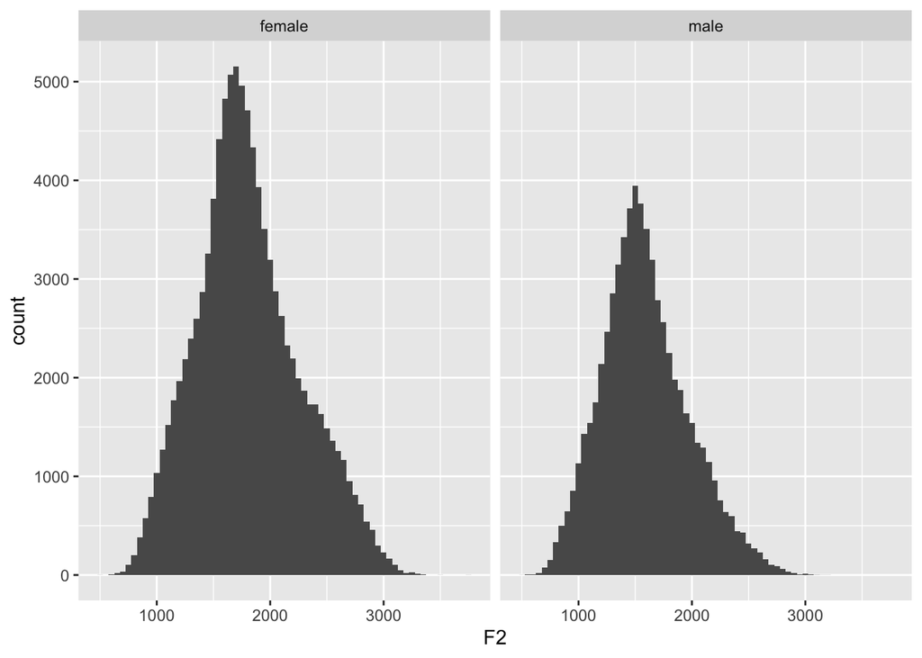

```r
ggplot(data = LIPP, aes(x = F2)) +
  geom_histogram(binwidth = 50) +
  facet_wrap(. ~ sex)
```

Having observed that the male & female speakers appear to have different F2 distributions, we might want to formally test this. A *t*-test is probably the simplest method for doing so, as it is designed to test one continuous variable - in this case F2 values - across two groups - in this case, speaker sex. The null hypothesis would be the assumption that the two distributions are statistically identical. *t* values greater than +/- 1.96 are considered significant, and would thus tell us we need to reject the null hypothesis and conclude that the distributions are different.

The formula for the t-test resembles that used in a wide variety of statistical tests. The two variables being used to subset the data are put first separated by a tilde. The dependent variable is placed first - this is the variable being tested. The second, independent variable is used to subset the data - the dataset will be split into groups based on this variable, which are then compared against each other. Finally, we specify the dataset.

```r
t.test(F2 ~ sex, data = LIPP)
```

```
##
##  Welch Two Sample t-test
##
## data:  F2 by sex
## t = 103.75, df = 152854, p-value < 2.2e-16
## alternative hypothesis: true difference in means is not equal to 0
## 95 percent confidence interval:
##  213.5988 221.8243
## sample estimates:
## mean in group female   mean in group male
##             1807.314             1589.603
```

The two most important results here are the *t* value and the *p* value. The *t* value tells us how great the difference is between the two groups, and the *p* value tells us whether this is likely to be a significant difference vs. just random chance.

In fact, the *p* value in a t-test is just derived from the *t* value, with *t* values greater than +/- 1.96 being considered significant. In any case, because the *t* value is quite large and the *p* value is extremely small, we can comfortably reject the null hypothesis, and conclude that the LIPP female vs. male F2 distributions are substantially and significantly different from each other.

It’s also possible to run a *one-sample t*-test, which we can easily do by simply selecting F2 as the test variable.

```r
t.test(LIPP$F2)
```

```
##
##  One Sample t-test
##
## data:  LIPP$F2
## t = 1571.6, df = 163654, p-value < 2.2e-16
## alternative hypothesis: true mean is not equal to 0
## 95 percent confidence interval:
##  1719.841 1724.136
## sample estimates:
## mean of x
##  1721.989
```

What does this result tell us? As the *alternative hypothesis* comment notes, this test determines that the true mean is not equal to zero. A mean of zero is the default setting for a one-sample *t*-test, but we can substitute any number we like by adding the `mu` argument to the `t.test()` – let’s try with 1715 Hz, which is *very* close to the true mean.

```r
t.test(x = LIPP$F2, mu = 1715)
```

```
##
##  One Sample t-test
##
## data:  LIPP$F2
## t = 6.3781, df = 163654, p-value = 1.798e-10
## alternative hypothesis: true mean is not equal to 1715
## 95 percent confidence interval:
##  1719.841 1724.136
## sample estimates:
## mean of x
##  1721.989
```

As we can see, the result here is still significant even in distinguishing between a mean and predicted value which are so close together, indicating how powerful the *t*-test can be. However, we should note carefully the difference between this and the earlier version where the mean was compared to a predicted value of zero: while both *p* values are quite small, indicative of significance (i.e. reject the null hypothesis), the *t* values are drastically different, indicating the relative effect size in each case. The first comparison to mean = zero has a *t* value of 1571.6, while the second comparison to mean = 1715 has a *t* value of only 6.4. So, the second test’s output does tell us that the mean is definitely not 1715, but also suggests that it’s not very far away from 1715, whereas the much higher *t* value of the first test indicates that the mean is indeed quite far from zero.

At any rate, when it comes to linguistic data, we are often looking at comparing across two groups, so the two-sample *t*-test is probably the more common implementation. Because the variable of sex/gender only has two levels in our data, male vs. female, the earlier 2-sample *t*-test covered everything we wanted to look at to evaluate the distributions relative to each other. Let’s next explore the use of the *t*-test a bit more using some of the other variables in the data file. We can get a quick view of the whole data table by simply entering its name in R.

```r
LIPP
```

```
## # A tibble: 163,655 x 28
##    speaker_id  year sex   filipino_id language english_status vowel stress
##         <dbl> <dbl> <chr>       <dbl> <chr>    <chr>          <chr>  <dbl>
##  1        201  1955 fema…           3 Tagalog  L2             AY         1
##  2        201  1955 fema…           3 Tagalog  L2             EY         1
##  3        201  1955 fema…           3 Tagalog  L2             IH         1
##  4        201  1955 fema…           3 Tagalog  L2             OW         1
##  5        201  1955 fema…           3 Tagalog  L2             IY         0
##  6        201  1955 fema…           3 Tagalog  L2             AE         1
##  7        201  1955 fema…           3 Tagalog  L2             AH         0
##  8        201  1955 fema…           3 Tagalog  L2             AY         1
##  9        201  1955 fema…           3 Tagalog  L2             AO         1
## 10        201  1955 fema…           3 Tagalog  L2             AH         0
## # … with 163,645 more rows, and 20 more variables: vowel_type <chr>, F1 <dbl>,
## #   F2 <dbl>, F3 <dbl>, dur <dbl>, pre_seg <chr>, fol_seg <chr>,
## #   fol_voice <chr>, fol_manner <chr>, fol_place <chr>, F1_20 <dbl>,
## #   F1_35 <dbl>, F1_50 <dbl>, F1_65 <dbl>, F1_80 <dbl>, F2_20 <dbl>,
## #   F2_35 <dbl>, F2_50 <dbl>, F2_65 <dbl>, F2_80 <dbl>
```

This quick view gives us the first 10 rows (i.e. observations) and 8 columns (i.e. variables) – we can also open the object from the Environment tab to view the entire data table for a more full view, but this is sufficient for now. Notice that we have both `language` and `english_status` variables. The latter refers to whether English (the language of the interviews) is the speaker’s first or second language. We can see how this variable breaks down pretty simply using the `table` function.

```r
table(LIPP$english_status)
```

```
##
##    L1    L2
## 83291 80364
```

We have pretty similar numbers of observations for each status. We can use the same *t*-test formula we performed earlier for speaker sex/gender, and see if F2 differs significantly according to English language status.

```r
t.test(F2 ~ english_status, data = LIPP)
```

```
##
##  Welch Two Sample t-test
##
## data:  F2 by english_status
## t = -0.75816, df = 163468, p-value = 0.4484
## alternative hypothesis: true difference in means is not equal to 0
## 95 percent confidence interval:
##  -5.957345  2.634038
## sample estimates:
## mean in group L1 mean in group L2
##         1721.173         1722.834
```

Recall that a *t* value of +/- 1.96 is usually considered significant. Becuase the *t* value of -0.75816 here is much smaller than +/- 1.96, we can not conclude that these two groups have different distributions. The high *p* value of 0.4484 also tells us we can not reject the null hypothesis that the two distributions are essentially the same. And, we can also see that the mean values are nearly identical, so this result makes sense.

In thinking about this some more, however, we still might want to examine the effect of first language status further – what if we compared speakers of different languages to each other? Let’s see the breakdown of the `language` variable.

```r
table(LIPP$language)
```

```
##
##     English     Ilocano Kapampangan     Tagalog
##       83291       22201       20126       38037
```

English predominates, but we have at least 20,000 observations in each of the other three languages. Let’s compare the two largest samples: English vs. Tagalog. To do this we need to change the formula in `t.test()` a little bit. We have to subset the data based on these two specific languages, using square brackets. And we will identify the two data subsets as the x and y variables inside `t.test()`:

```r
t.test(x = LIPP$F2[LIPP$language == "English"],
       y = LIPP$F2[LIPP$language == "Tagalog"])
```

```
##
##  Welch Two Sample t-test
##
## data:  LIPP$F2[LIPP$language == "English"] and LIPP$F2[LIPP$language == "Tagalog"]
## t = -1.2002, df = 76685, p-value = 0.2301
## alternative hypothesis: true difference in means is not equal to 0
## 95 percent confidence interval:
##  -8.425871  2.025685
## sample estimates:
## mean of x mean of y
##  1721.173  1724.373
```

This time the *t* value is a little larger, though still small, and the means are a tiny bit further apart. The large *p* value indicates we cannot reject the null hypothesis, and have to conclude these distributions are not statistically different from each other.

What about English vs. the other two languages, Ilocano and Kapampangan?

```r
t.test(x = LIPP$F2[LIPP$language == "English"],
       y = LIPP$F2[LIPP$language == "Ilocano"])
```

```
##
##  Welch Two Sample t-test
##
## data:  LIPP$F2[LIPP$language == "English"] and LIPP$F2[LIPP$language == "Ilocano"]
## t = -30.725, df = 32266, p-value < 2.2e-16
## alternative hypothesis: true difference in means is not equal to 0
## 95 percent confidence interval:
##  -119.9596 -105.5721
## sample estimates:
## mean of x mean of y
##  1721.173  1833.938
```

```r
t.test(x = LIPP$F2[LIPP$language == "English"],
       y = LIPP$F2[LIPP$language == "Kapampangan"])
```

```
##
##  Welch Two Sample t-test
##
## data:  LIPP$F2[LIPP$language == "English"] and LIPP$F2[LIPP$language == "Kapampangan"]
## t = 40.506, df = 35097, p-value < 2.2e-16
## alternative hypothesis: true difference in means is not equal to 0
## 95 percent confidence interval:
##  117.8143 129.7957
## sample estimates:
## mean of x mean of y
##  1721.173  1597.368
```

For each of these tests we get much larger *t* values, and miniscule *p* values which indicate statistical significance. The mean F2 values in each case are more than 100 Hz apart, though in different directions: Ilocano speakers have a higher mean F2 indicating more fronted vowel production overall, while Kapampangan speakers have a lower F2, so more retracted vowel production overall.

Out of curiosity, what do these distributions look like in a plot? A density plot will accommodate the different token counts in each language - we can set the `fill` aesthetic to assign colour according to the `lanaguage` variable, and set a low `alpha` value inside `geom_density()` to allow us to see through the overlapping distributions

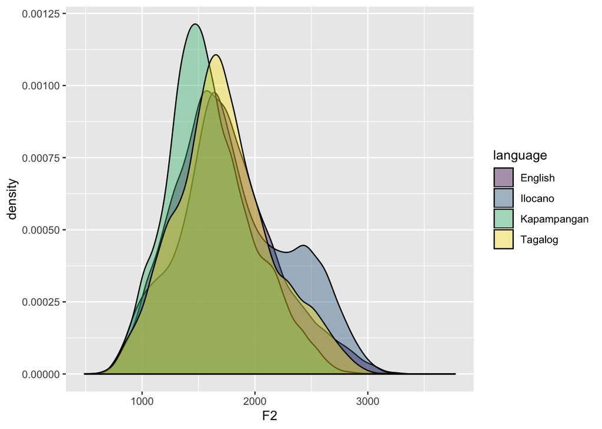

```r
LIPP %>%
  ggplot(aes(x = F2, fill = language)) +
  geom_density(alpha = 0.4) +
  scale_fill_viridis_d()
```

It’s a little bit hard to read this, but we can see that the peak of the Kapampangan distribution is much lower on the F2 scale than the other languages. The other three largely overlap where their peaks are, but Ilocano has a bimodal distribution with a second, smaller peak at a higher F2 which bumps up its overall mean - hence the results we got earlier from the t-test.

> **Note:** We probably shouldn’t conclude too much from these comparisons, as we are aggregating *all* of the vowels together here, so it’s not very clear what these F2 differences actually mean. But we are just exploring the data and learning how to run these tests here, rather than trying to reach any large conclusions about the data.

We started with a comparison of F2 across the two language statuses in the data, and got a non-significant result. But, when we dug down a little further using the 4-level `language` variable, we discovered that there were some hidden differences which were significant. Furthermore, we haven’t even explored this completely, as we could compare each language against each other language, rather than only looking at English vs. the others one by one. That would involve three additional *t*-tests. And if our variable had more than four levels (such as `vowel`), we would need even more tests. There must be a simpler method!

R has a built-in test for doing pairwise comparisons, i.e. exhaustively testing one pair at a time from all groups being considered. `pairwise.t.test()` produces a table of *p* values for each comparison, however it does not provide any other analysis.

```r
pairwise.t.test(LIPP$F2, LIPP$language)
```

```
##
##  Pairwise comparisons using t tests with pooled SD
##
## data:  LIPP$F2 and LIPP$language
##
##             English Ilocano Kapampangan
## Ilocano     <2e-16  -       -
## Kapampangan <2e-16  <2e-16  -
## Tagalog     0.24    <2e-16  <2e-16
##
## P value adjustment method: holm
```

The results here are just the *p* values which we obtained in the individual t-tests earlier.

## 2.2 ANOVA

An alternative to the pairwise t-test is the Analysis of Variance or ANOVA, which was designed to extend the power of the *t*-test beyond two groups or categories. ANOVAs can be carried out with the `aov()` function using the formula: `dependent.variable ~ independent.variable` and selecting the data. Typically, the ANOVA is first stored as an object (which we will call `LIPPanova`) and then `summary()` is used to report the results. We’ll see why shortly.

```r
LIPPanova <- aov(F2 ~ language, data = LIPP)
summary(LIPPanova)
```

```
##                 Df    Sum Sq   Mean Sq F value Pr(>F)
## language         3 5.911e+08 197025434    1022 <2e-16 ***
## Residuals   163651 3.156e+10    192875
## ---
## Signif. codes:  0 '***' 0.001 '**' 0.01 '*' 0.05 '.' 0.1 ' ' 1
```

The ANOVA tests the null hypothesis that the dependent and independent variables, here being `F2` and `language`, are not correlated. Here, the very low *p* value indicates that there is good reason to reject this and conclude that there *is* a correlation between these – but the ANOVA doesn’t provide any more detail than this on its own.

However, the ANOVA can be combined with the Tukey HSD (“honest significant difference”) test to produce a more thorough analysis which includes pairwise comparisons across each group level. This is where the stored ANOVA object comes in handy, as we need to enter it into the `TukeyHSD()` function:

```r
TukeyHSD(LIPPanova)
```

```
##   Tukey multiple comparisons of means
##     95% family-wise confidence level
##
## Fit: aov(formula = F2 ~ language, data = LIPP)
##
## $language
##                            diff         lwr        upr    p adj
## Ilocano-English      112.765844  104.244029  121.28766 0.000000
## Kapampangan-English -123.804994 -132.666874 -114.94311 0.000000
## Tagalog-English        3.200093   -3.782006   10.18219 0.641127
## Kapampangan-Ilocano -236.570838 -247.552078 -225.58960 0.000000
## Tagalog-Ilocano     -109.565751 -119.094887 -100.03662 0.000000
## Tagalog-Kapampangan  127.005087  117.170657  136.83952 0.000000
```

Note that the *p* values in the pairwise test results indicate that only the Tagalog-English comparison produces a result which lacks statistical significance, although the exact *p* value differs from the one we got for the t-test, and for the ANOVA as a whole. This should be an indication that the *p* value does not always tell the whole story, and it’s worth taking the time to understand what tests are reporting *aside* from the *p* value.

## 2.3 Variance and test selection

Paired t-tests and ANOVAs are called “parametric” tests, which are designed for data which is normally distributed. If the data are not normally distributed, e.g. if one or multiple subsets of the data are skewed, then the variance across these groups is not equal, and these tests may not be appropriate.

*Levene’s test for homogeneity of variance* is designed to test if we have non-parametric (i.e. not normally-distributed) data. To run this test I’m using the `leveneTest()` function included in the `car` (“Companion to Applied Regression”) so we’ll need to install and load that first:

```r
if(!require(car)){install.packages("car")}
library(car)

leveneTest(F2 ~ language, data = LIPP)
```

```
## Levene's Test for Homogeneity of Variance (center = median)
##           Df F value    Pr(>F)
## group      3  589.69 < 2.2e-16 ***
##       163651
## ---
## Signif. codes:  0 '***' 0.001 '**' 0.01 '*' 0.05 '.' 0.1 ' ' 1
```

The low *p* value indicates that the groups in the independent variable (i.e. the different first languages associated with the various speakers) do have significantly differ variances within their respective distributions. This suggests that our earlier ANOVA was perhaps not an appropriate test for this data.

There are a few alternatives to the standard ANOVA. One is the “Kruskal-Wallis rank sum test” – the `kruskal.test()` function is included with the `stats()` package:

```r
if(!require(stats)){install.packages("stats")}
library(stats)

kruskal.test(F2 ~ language, data = LIPP)
```

```
##
##  Kruskal-Wallis rank sum test
##
## data:  F2 by language
## Kruskal-Wallis chi-squared = 2728.3, df = 3, p-value < 2.2e-16
```

There is even a form of the ANOVA – Welch’s one-way ANOVA – which doesn’t assume equal variances.

```r
oneway.test(F2 ~ language, data = LIPP)
```

```
##
##  One-way analysis of means (not assuming equal variances)
##
## data:  F2 and language
## F = 1096.2, num df = 3, denom df = 56172, p-value < 2.2e-16
```

And furthermore, the pairwise *t*-test which we saw earlier *can* be implemented for non-equal-variance comparisons by not pooling the standard deviations across groups.

```r
pairwise.t.test(LIPP$F2, LIPP$language, pool.sd = FALSE)
```

```
##
##  Pairwise comparisons using t tests with non-pooled SD
##
## data:  LIPP$F2 and LIPP$language
##
##             English Ilocano Kapampangan
## Ilocano     <2e-16  -       -
## Kapampangan <2e-16  <2e-16  -
## Tagalog     0.23    <2e-16  <2e-16
##
## P value adjustment method: holm
```

None of these tests provide the level of detail of the ANOVA – but they all confirm that there are significant differences in F2 by first language, and the non-pooled pairwise t-test even gives near-identical results in terms of *p* values as the pooled version. What does this indicate? And do we need to worry about how parametric our data is?

The Central Limit Theorem (CLT) tells us that repeated random sampling will produce means which fall into a normal distribution, even when the originating data does not contain a precisely normal distribution. This is something like (but a bit different) what we saw when we took random samples in increasingly large numbers – the mean-median difference got progressively smaller as more data was added.

The practical impact of this is that, for very large datasets, it’s usually sufficient to use parametric tests (e.g. *t*-tests, ANOVAs, etc.) even when the data may not be normally distributed, and even when you *know* that it isn’t! The only real issue with the CLT is that it is not known precisely what constitutes a “large enough” dataset. The dataset we are using here, with > 160,000 observations, seems to be substantially large enough that the CLT allows us to run parametric tests despite the data being underlyingly non-parametric. If your dataset is much smaller and you’re unsure whether to use a parametric or non-parametric test, it’s probably advisable to use a non-parametric test.

Sonderegger et al. actually advise avoiding *t*-tests entirely and use the non-parametric Wilcoxon test instead:

```r
wilcox.test(LIPP$F2[LIPP$sex == "male"],
            LIPP$F2[LIPP$sex == "female"])
```

```
##
##  Wilcoxon rank sum test with continuity correction
##
## data:  LIPP$F2[LIPP$sex == "male"] and LIPP$F2[LIPP$sex == "female"]
## W = 2290248570, p-value < 2.2e-16
## alternative hypothesis: true location shift is not equal to 0
```

They note that for genuinely normal distributions, *t*-tests will produce more accurate *p* values, but that this is usually a small difference, and the Wilcoxon test is better as a general test. I don’t have enough experience evaluating the difference between the two tests to make a strong claim one way or the other, but it is certain that the *t*-test is one of the most familiar statistical tests in wide usage, so it has a strong level of familiarity.

Hopefully the set of tests provided here give you a range of options to use – but there are many, many other tests available.

## 2.4 Standard deviation, standard error and confidence intervals

We discussed one of the basic statistical measures, the *standard deviation* or S.D., in the context of random data samples earlier. What is the S.D. of the LIPP F2 distribution?

```r
sd(LIPP$F2)
```

```
## [1] 443.2645
```

S.D. is a measure of variance in the sample data being examined – a low S.D. indicates that most values are close to the mean, while larger values indicate that they are more spread out. While S.D. is a measure of the sample which we have, another similarly-named measure is the *standard error (of the mean)* or S.E. This tells us how likely it is that our sample – or specifically, its mean value – is a good estimate of the mean of larger population.

> The basic concept behind statistical testing is that there is a true population – in the case of linguistic data, this might be every single speaker of a language – which we take a sample of, because we can never really exhaustively examine the entire population. Statistical tests are used to try and evaluate how likely it is that what we see in our sample is representative of what the population actually looks like – but of course, we never really know for certain since we can’t test the entire population (in most cases).

There is no default function to calculate S.E. in R, but the formula is fairly straightforward, and can be calculated in two ways. I’ll use `function()` to create two S.E. functions – `se1` and `se2` – and then enter the LIPP F2 data into each one to show that they get the same result:

```r
se1 <- function(x) sqrt(var(x)/length(x))
se2 <- function(x) sd(x)/sqrt(length(x))

se1(LIPP$F2)
```

```
## [1] 1.095717
```

```r
se2(LIPP$F2)
```

```
## [1] 1.095717
```

The basic difference between S.D. and S.E. is that the former tells us about the distribution of variation *within our sampled data*, and S.E. tells us about *how well our sample is representative of the larger population*. S.E. also allows us to compute Confidence Intervals (CIs) which tell us where the true mean likely lies. If the S.E. is relatively small as compared to the S.D., then the confidence in our calculated mean falling close to the real mean is extremely high. CIs can be calculated for any percentage of the data range, but are typically calculated at 95% – that is, the mean is estimated to fall within the CI range 95% of the time, which is generally accepted as the default for statistical signficance (cf. that 0.05 is the most commonly-used *p* value in many social sciences).

CIs at 95% are equivalent to 1.96 times the S.E. +/- the mean. We can calculate all of these individually:

```r
# Mean of F2
mean(LIPP$F2)
```

```
## [1] 1721.989
```

```r
# Standard Error of F2
se1(LIPP$F2)
```

```
## [1] 1.095717
```

```r
# Lower 95% confidence interval of F2: 1.96 * S.E. below the mean
mean(LIPP$F2)-1.96*se1(LIPP$F2)
```

```
## [1] 1719.841
```

```r
# Upper 95% confidence interval of F2: 1.96 * S.E. above the mean
mean(LIPP$F2)+1.96*se1(LIPP$F2)
```

```
## [1] 1724.136
```

As an alternative, the `ci()` function in the `gmodels` package does the calculations for us, providing all the same numbers:

```r
if(!require(gmodels)){install.packages("gmodels")}
library(gmodels)
ci(LIPP$F2)
```

```
##    Estimate    CI lower    CI upper  Std. Error
## 1721.988541 1719.840959 1724.136122    1.095717
```